# A3: Incarceration

### Introduction

This data analysis and visualization on incarceration involve both the prison population and jail population. As a student in Seattle, which is the county seat of King County, Washington, I am interested in the prison population rate in King County, WA. Because policies or people’s perceptions change over time, I’d like to know the historical peaks of prison population rates and variations in different races since 1990 in King County, WA. Since racial and sexual injustice and oppression are always intertwined, I am also curious if there is any possible hint on the relation or intersection of sexual and racial issues. Thus, I intend to analyze the data on male and female prison population rates, along with the race that has the highest prison population rate in each county. Unlike the prison population, for the jail population, I am more inclined to base my analysis on states and focus on the latest year. Geographic divisions perhaps suggest some kind of discriminatory, oppressive, or prejudicial geographic tendency, so I intend to see the geographical distribution of the total jail population across the U.S. and the corresponding race that has appeared most frequently as the race with the highest jail population rate. I expect to find some commonalities in the geographic distribution.

### The Dataset

- Vera Institute of Justice collected the data. Vera generated their data from two Bureau of Justice Statistics (BJS) data collections: the Census of Jails (COJ) and the Annual Survey of Jails (ASJ). They continued to update their data from COJ and ASJ. Vera created the data because they intended to provide county-level data that could satisfy the level of detail necessary to unpack the causes and consequences of incarceration in the United States. Research on incarceration had traditionally centered on state-level data, which was less sufficient in detailed research compared with county-level data
- There are 91,031 observations (rows) and 26 features (columns) in the first data set(rate data), and there are 153,811 observations (rows) and 28 features (columns) in the second data set(population data).
- Ethical questions or questions of power: Since Vera collected data from the Bureau of Justice Statistics (BJS), one thing to consider is to challenge the power/authority. The benefit of authority is comprehensiveness, as Vera was able to collect detailed data at the county level. However, the final statistics displayed by BJS perhaps has been through multiple “treatments”. We have no way of knowing the details of the data from the county level to the final data in the Census of Jails (COJ) and the Annual Survey of Jails (ASJ), such as how they sorted, merged, and cropped outliers. These statistical institutions may be part of components of the matrix of domination, and thus they may stand for the dominated groups. Since there was data on different ethical groups and genders, which may involve some potential ethical or sexual inequalities and bias, we shall not assume that these observations and features are completely accurate and uncontroversial simply because they are collected from these authorities.
- Limitations: One limitation of this data is that these data sets only include results. They only provide final numbers such as the jail population rate or prison population. In order to better understand and analyze if there are some racial or sexual discriminations implied by the data sets, I think it would be more sufficient if they could also classify the data by reasons for incarcerations. Another limitation of this data is that there are only two categories of gender, whereas many people have gender identities other than male or female. Thus, the data involving gender may be inaccurate or over-generalized.

### Trends Over Time Chart

I designed and included this chart because I intended to find the changes in prison population rate over time in King County, Washington, and the variances with different races. After I calculated the year that the highest total prison population rate in King County occurred, I was wondering if the similar high-level prison population rate also stood out for every race in nearby years, and how they maintained or changed after that. Particularly, I intended to show a visual comparison of different races’ prison population rates (prison population per 100,000 people) with this chart to find if there are implications of discrimination or bias. This chart clearly shows the difference in prison population rates between races. Since 1990, blacks have always had a higher prison population rate than the other three races. The peak of the Black prison population rate is also around 1996, which is in line with the year with the highest total prison population rate I calculated before. However, prison population rates for other races do not correlate well with this year. In addition, according to the graph, the Black prison population rate changes the most, and after 2002, this rate has almost always been trending downward. Native American prison population rate has always varied a lot, but the difference between the maximum and minimum rates is not as large as for blacks. Asian American/Pacific Islanders and Whites always keep a relatively low prison population rate, and almost have no variations as year changes.

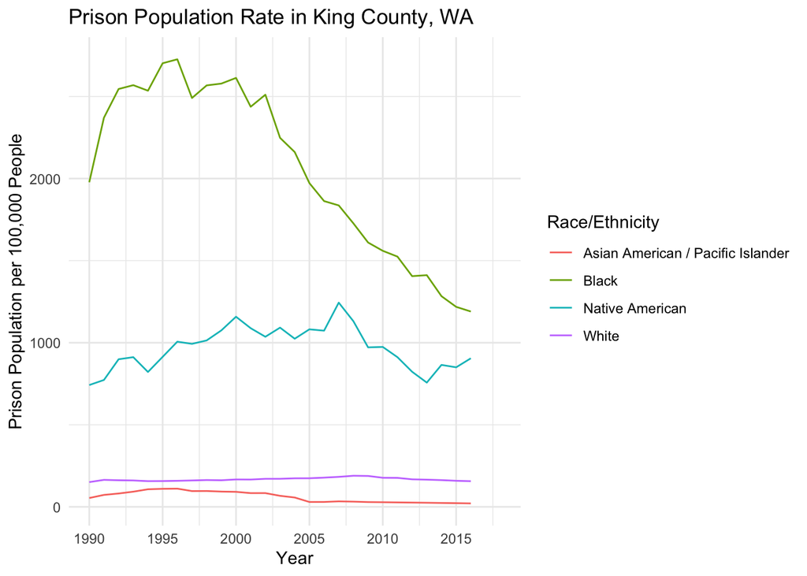

### Variable Comparison Chart

I designed and included this chart in order to show the potential relationship between male and female prison population rates and their relation with different races. I classified each county’s data point’s color by the race with the highest prison population rate(prison population per 100,000 people), and I drew a linear regression line for each race group to see if the male and female prison population rates were more strongly related when a race had the highest prison population rate, and this pattern may suggest that gender inequality and racial inequality were intertwined. The most obvious pattern is that every linear regression line has a positive slope, so generally, an increase in female female prison population rate is along with an increase in the male prison population rate. For each race, the data points aren’t closely clustered around the line, so these looser fits indicate that there are still variabilities in the positive relationship between male and female prison population rates. Asian American/Pacific Islanders have the steepest line, so this positive relationship is strongest among Asian American/Pacific Islanders. Black has the second steepest line, which also indicates a strong positive relationship, but their data points are also more discrete. The lines of Latinx, Native American, and White are very close, which implies that they both have similarly loose positive relationships between male and female prison population rates.

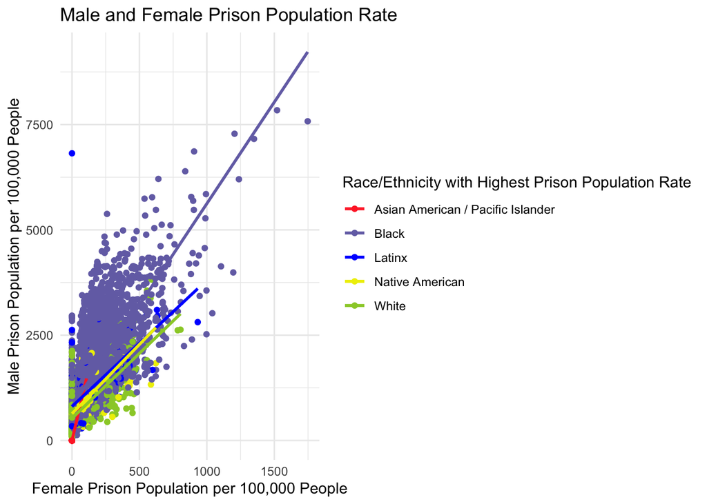

### Map

I designed and included this map to reflect the most recent (according to the data set, the latest year is 2018) jail population distribution across the U.S. in order to show and compare the total jail population in each state and the race that has appeared most frequently as the race with highest jail population rate in counties of each state. I intend to find and analyze the geographic distributions and differences between the jail population and the most frequent races. This map reveals that compared with northern states, southern states are more likely to have a higher total jail population. Compared with western states (except California), eastern states are more likely to have a higher total jail population. In most states, blacks appear the most frequently as the race with the highest jail population rate, and in some northern states, Native Americans appear the most frequently as the race with the highest jail population rate. I did use the full data set filtered by 2018, but only these two races appear on the final map.

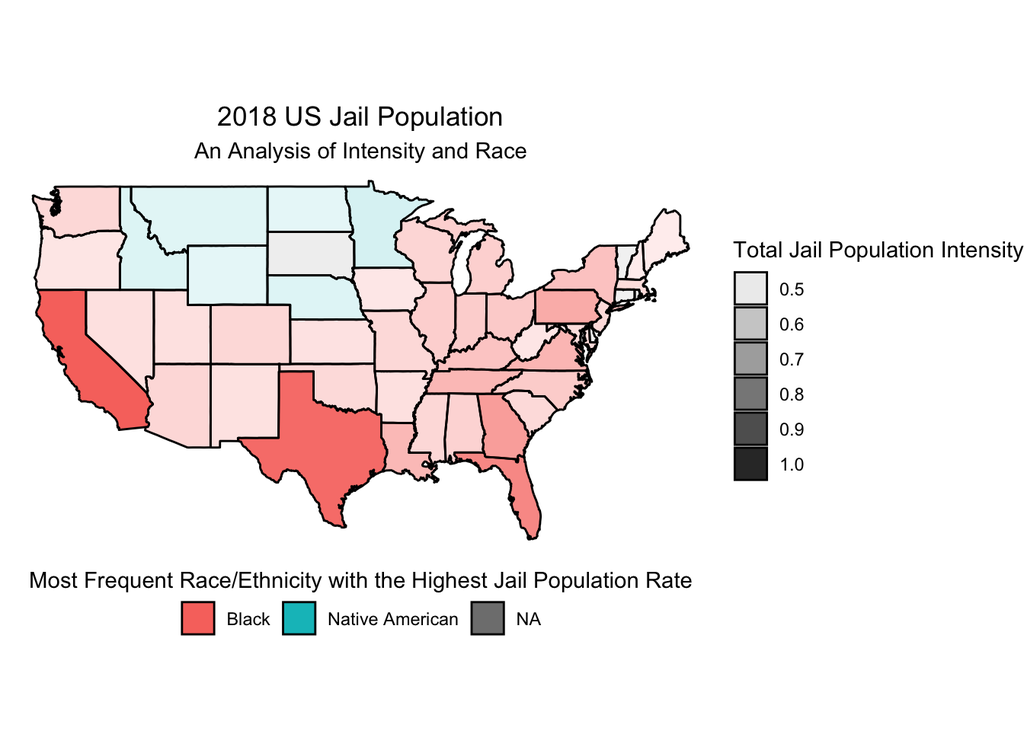